# Part ivA: Interpretation (Intro)

INFSCI 2595 Final

Ben Stein

4/27/2022

# About this document

In this document, I begin interpreting my results. I identify the strongest models for regression and classification, examine and compare their variables, and attempt to answer the question of whether the sentiment-based variables are useful in predicting the outputs.

# Setup

## Libraries & tools

```r
library(tidyverse)
library(caret)
library(vip)
source("./tools.R")
```

## Data

```r
df <- load_project_data()
```

## “Best” models

```r
best_reg_model <- load_model("adv_reg_model10_svm_rbf.rds")
best_cls_model <- load_model("adv_class_model4_continuous_linear.rds")
```

# Best models

## Regression

My best performing regression model was an SVM-based model using a radial basis function. Let’s take a look at a quick summary:

### Metrics

```r
best_reg_model$results %>%
  filter(
    sigma == best_reg_model$bestTune$sigma & C == best_reg_model$bestTune$C
  )
```

```
##   C sigma      RMSE  Rsquared       MAE     RMSESD RsquaredSD      MAESD
## 1 1  0.01 0.2861085 0.7210153 0.2218851 0.02531451 0.03926713 0.01601959
```

### Variable importance

**NOTE:** My best model is the SVM; however, I had trouble getting variable importance working:

```r
vip::vip(best_reg_model$finalModel)
```

```
## Error: Model-specific variable importance scores are currently not available for this type of model.
```

Instead, I’ll examine variable importance for my second-best model, which is an XGBoost model:

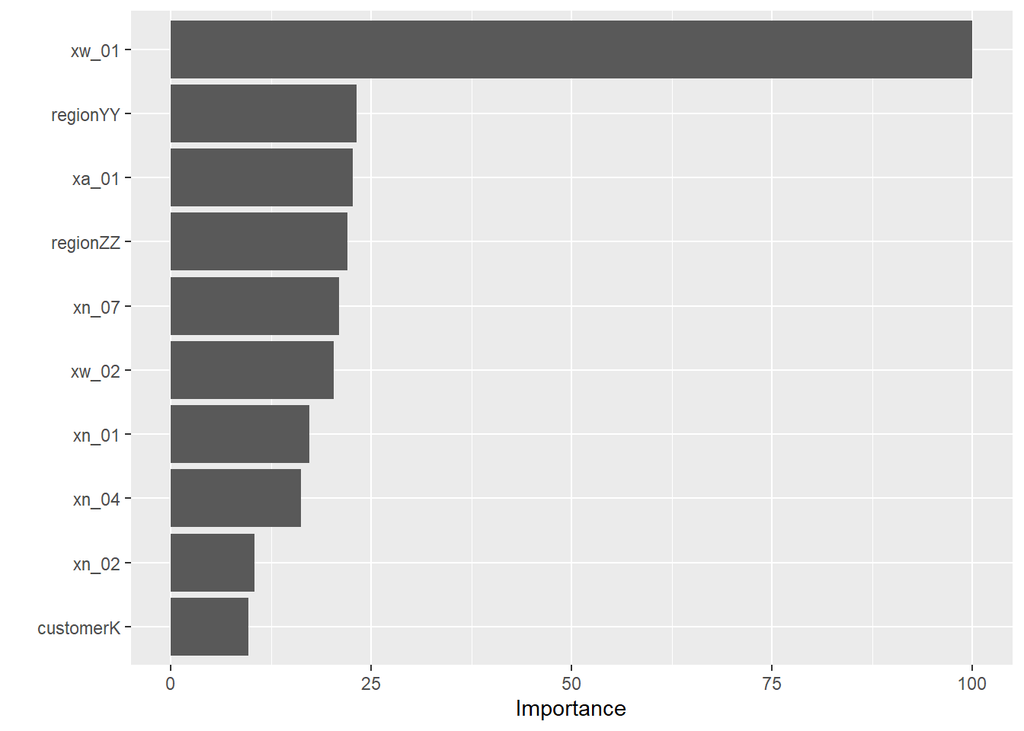

```r
best_reg_model2 <- load_model("adv_reg_model9_xgb.rds")
vip::vip(best_reg_model2)
```